# Predicting Coupon Redemption

Anushree Tomar

28 September 2019

XYZ Credit Card company regularly helps it’s merchants understand their data better and take key business decisions accurately by providing machine learning and analytics consulting. ABC is an established Brick & Mortar retailer that frequently conducts marketing campaigns for its diverse product range. As a merchant of XYZ, they have sought XYZ to assist them in their discount marketing process using the power of machine learning.

Discount marketing and coupon usage are very widely used promotional techniques to attract new customers and to retain & reinforce loyalty of existing customers. The measurement of a consumer’s propensity towards coupon usage and the prediction of the redemption behaviour are crucial parameters in assessing the effectiveness of a marketing campaign.

ABC’s promotions are shared across various channels including email, notifications, etc. A number of these campaigns include coupon discounts that are offered for a specific product/range of products. The retailer would like the ability to predict whether customers redeem the coupons received across channels, which will enable the retailer’s marketing team to accurately design coupon construct, and develop more precise and targeted marketing strategies.

## Datasets

The data available in this problem contains the following information, including the details of a sample of campaigns and coupons used in previous campaigns -

- User Demographic Details
- Campaign and coupon Details
- Product details
- Previous transactions

## Problem Statement

Based on previous transaction & performance data from the last 18 campaigns, predict the probability for the next 10 campaigns in the test set for each coupon and customer combination, whether the customer will redeem the coupon or not?

## Data Exploration

List of all given datasets-

```
[1] "campaign_data.csv"             "coupon_item_mapping.csv"
[3] "customer_demographics.csv"     "customer_transaction_data.csv"
[5] "item_data.csv"                 "test_QyjYwdj.csv"
[7] "train.csv"
```

Analyse all datasets-

```
                     [,1] [,2]   [,3]  [,4]     [,5]    [,6]   [,7]
rows                 28   92663  760   1324566  74066   50226  78369
columns              4    2      7     7        4       4      5
discrete_columns     3    0      4     1        2       0      0
continuous_columns   1    2      3     6        2       4      5
all_missing_columns  0    0      0     0        0       0      0
total_missing_values 0    0      0     0        0       0      0
complete_rows        28   92663  760   1324566  74066   50226  78369
total_observations   112  185326 5320  9271962  296264  200904 391845
memory_usage         5944 742664 36824 58318400 1780664 805368 1569408
```

## Observe all the data

Lets see the observations of the data.

```
[1] "campaign_data.csv"             "coupon_item_mapping.csv"
[3] "customer_demographics.csv"     "customer_transaction_data.csv"
[5] "item_data.csv"                 "test_QyjYwdj.csv"
[7] "train.csv"
[[1]]
   campaign_id campaign_type start_date end_date
1:          24             Y   21/10/13 20/12/13
2:          25             Y   21/10/13 22/11/13

[[2]]
   coupon_id item_id
1:       105      37
2:       107      75

[[3]]
   customer_id age_range marital_status rented family_size no_of_children income_bracket
1:           1       70+        Married      0           2                             4
2:           6     46-55        Married      0           2                             5

[[4]]
         date customer_id item_id quantity selling_price other_discount coupon_discount
1: 2012-01-02        1501   26830        1         35.26         -10.69               0
2: 2012-01-02        1501   54253        1         53.43         -13.89               0

[[5]]
   item_id brand  brand_type      category
1:       1     1 Established       Grocery
2:       2     1 Established Miscellaneous

[[6]]
   id campaign_id coupon_id customer_id
1:  3          22       869         967
2:  4          20       389        1566

[[7]]
   id campaign_id coupon_id customer_id redemption_status
1:  1          13        27        1053                 0
2:  2          13       116          48                 0
```

## Examine the Redemption Status

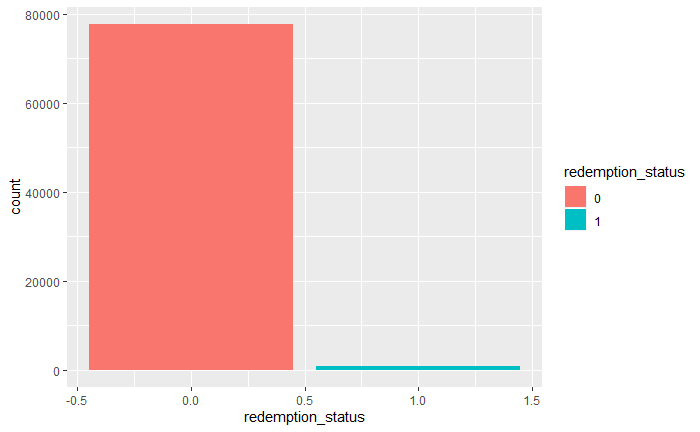

The Proportion of redemption status is unbalnced so we need to balance the status before creating any prediction model.

## Campaign Data

Calculate the duration of campaign

```
   campaign_id campaign_type campaign_duration
1:          24             Y           60 days
2:          25             Y           32 days
3:          20             Y           70 days
4:          23             Y           38 days
5:          21             Y           32 days
6:          22             X           32 days
```

## Analyse campaign type

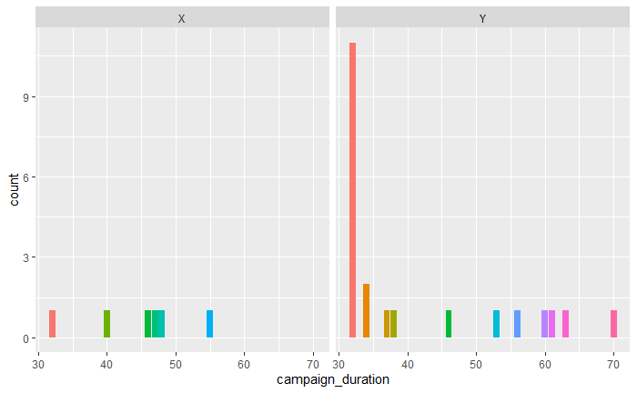

As from the above graph we can see that more duraion spend on the campaign type Y

## Combine train data and campaign data

In the train data we merged the campaign data by “campaign_id”

## Customer demographics data

```
  customer_id age_range marital_status rented family_size no_of_children income_bracket
1           1       70+        Married      0           2           <NA>              4
2           6     46-55        Married      0           2           <NA>              5
3           7     26-35           <NA>      0           3              1              3
4           8     26-35           <NA>      0           4              2              6
5          10     46-55         Single      0           1           <NA>              5
6          11       70+         Single      0           2           <NA>              1
```

```
   customer_id      age_range marital_status         rented    family_size no_of_children
             0              0            329              0              0            538
income_bracket
             0
```

As we can see that some customer demographics data as *marital_status* and *no_of_children* is not available so we need to fill the missing values.

## Visualise Customer demographics

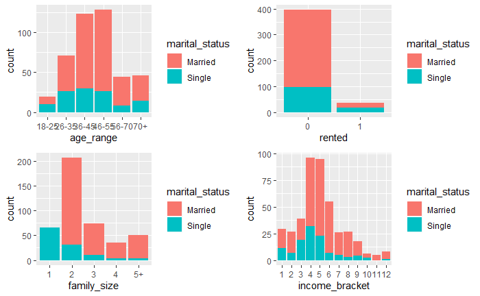

From the above graph we can see that most of the customers are married and having age range *46-55*,*36-45*, family size of *2* with income bracket of *4*,*5* and not rented.

- Impute *no_of_children*

```
  1   2  3+
107  55  60
```

There are 3 levels in the *no_of_children* 1,2, and 3+ so we will fill the missing value with “0”

```
  1   2  3+   0
107  55  60 538
```

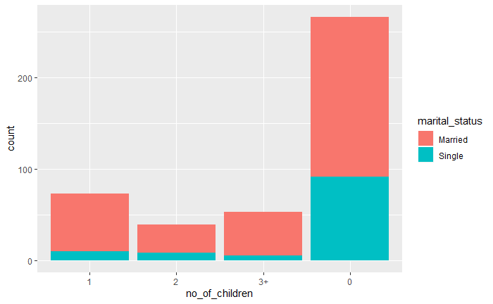

- Impute *marital_status*

To impute *marital_status* we need to focus on family_size and no_of_children. most of the single customers have *family size*- 1 and 0 -*no_of_children*

```
     customer_id age_range marital_status rented family_size no_of_children income_bracket
[1,]           1         6              1      1           2              4              4
[2,]           6         4              1      1           2              4              5
[3,]           7         2              1      1           3              1              3
[4,]           8         2              1      1           4              2              6
[5,]          10         4              2      1           1              4              5
[6,]          11         6              2      1           2              4              1
```

## Item data

```
  item_id brand  brand_type      category
1       1     1 Established       Grocery
2       2     1 Established Miscellaneous
3       3    56       Local        Bakery
4       4    56       Local       Grocery
5       5    56       Local       Grocery
6       6    56       Local       Grocery
```

## Coupon Item mapping data

```
  coupon_id item_id
1       105      37
2       107      75
3       494      76
4       522      77
5       518      77
6       520      77
```

```
  item_id coupon_id brand  brand_type       category
1       1        22     1 Established        Grocery
2       1        31     1 Established        Grocery
3       4       327    56       Local        Grocery
4       4        82    56       Local        Grocery
5       4       166    56       Local        Grocery
6       7        23    56       Local Pharmaceutical
```

In the coupon_item_mapping data we added the information of items by item_id

## brand type

```
Established       Local
      78759       13904
```

## Count of brand type by coupon id

```
  coupon_id Established Local
1         1          39     0
2         2           2     0
3         3          17     0
4         4          24     0
5         5           7     0
6         6        3075   638
```

```
  coupon_id Established       Local
     623286       78759       13904
```

## Count of Category by coupon id

```
  coupon_id Bakery Dairy, Juices & Snacks Flowers & Plants Garden Grocery Meat Miscellaneous
1         1      0                      0                0      0       9    0             0
2         2      0                      0                0      0       2    0             0
3         3      0                      0                0      0      17    0             0
4         4      0                      0                0      0      24    0             0
5         5      0                      0                0      0       0    0             0
6         6      0                    259                0      0    3082    2             0
  Natural Products Packaged Meat Pharmaceutical Prepared Food Restauarant Salads Seafood
1               30             0              0             0           0      0       0
2                0             0              0             0           0      0       0
3                0             0              0             0           0      0       0
4                0             0              0             0           0      0       0
5                0             0              7             0           0      0       0
6                0           242              0             0           0      0     128
  Skin & Hair Care Travel Vegetables (cut)
1                0      0                0
2                0      0                0
3                0      0                0
4                0      0                0
5                0      0                0
6                0      0                0
```

```
             coupon_id                 Bakery Dairy, Juices & Snacks       Flowers & Plants
                623286                    100                   1867                   1963
                Garden                Grocery                   Meat          Miscellaneous
                   286                  36466                   6218                    184
      Natural Products          Packaged Meat         Pharmaceutical          Prepared Food
                  6819                   6144                  25061                    240
           Restauarant                 Salads                Seafood       Skin & Hair Care
                     1                    100                   2227                   4924
                Travel       Vegetables (cut)
                    44                     19
```

## Customer Transaction data

```
        date customer_id item_id quantity selling_price other_discount coupon_discount
1 2012-01-02        1501   26830        1         35.26         -10.69               0
2 2012-01-02        1501   54253        1         53.43         -13.89               0
3 2012-01-02        1501   31962        1        106.50         -14.25               0
4 2012-01-02        1501   33647        1         67.32           0.00               0
5 2012-01-02        1501   48199        1         71.24         -28.14               0
6 2012-01-02        1501   57397        1         71.24         -28.14               0
```

From the above data we will analyse customers purchasing pattern by RFM analysis then will calculate Final price after discount.

## Summarize Final traindata

```
 redemption_status campaign_duration       X                Y          age_range
 0:77640           Min.   :32.00     Min.   :0.0000   Min.   :0.0000   18-25: 2456
 1:  729           1st Qu.:46.00     1st Qu.:0.0000   1st Qu.:0.0000   26-35: 8024
                   Median :47.00     Median :1.0000   Median :0.0000   36-45:11210
                   Mean   :44.77     Mean   :0.7361   Mean   :0.2639   46-55:49862
                   3rd Qu.:48.00     3rd Qu.:1.0000   3rd Qu.:1.0000   56-70: 3723
                   Max.   :63.00     Max.   :1.0000   Max.   :1.0000   70+  : 3094

 marital_status  rented    family_size no_of_children income_bracket   Established
 Married:61992   0:75864   1 :13612    1 : 6540       5      :45745   Min.   :    0
 Single :16377   1: 2505   2 :51596    2 : 3547       4      : 8753   1st Qu.:    2
                           3 : 6267    3+: 3969       6      : 4855   Median :    8
                           4 : 3139    0 :64313       2      : 3892   Mean   :   70
                           5+: 3755                   3      : 3882   3rd Qu.:   27
                                                      1      : 3456   Max.   :10744
                                                      (Other): 7786
     Local             Bakery         Dairy, Juices & Snacks Flowers & Plants      Garden
 Min.   :   0.00   Min.   : 0.00000   Min.   :  0.000        Min.   :  0.000   Min.   : 0.0000
 1st Qu.:   0.00   1st Qu.: 0.00000   1st Qu.:  0.000        1st Qu.:  0.000   1st Qu.: 0.0000
 Median :   0.00   Median : 0.00000   Median :  0.000        Median :  0.000   Median : 0.0000
 Mean   :  11.93   Mean   : 0.09081   Mean   :  1.868        Mean   :  1.708   Mean   : 0.2483
 3rd Qu.:   0.00   3rd Qu.: 0.00000   3rd Qu.:  0.000        3rd Qu.:  0.000   3rd Qu.: 0.0000
 Max.   :1171.00   Max.   :16.00000   Max.   :260.000        Max.   :652.000   Max.   :95.0000

    Grocery             Meat          Miscellaneous     Natural Products   Packaged Meat
 Min.   :   0.00   Min.   :   0.000   Min.   : 0.0000   Min.   :   0.000   Min.   :   0.000
 1st Qu.:   0.00   1st Qu.:   0.000   1st Qu.: 0.0000   1st Qu.:   0.000   1st Qu.:   0.000
 Median :   6.00   Median :   0.000   Median : 0.0000   Median :   0.000   Median :   0.000
 Mean   :  34.38   Mean   :   5.869   Mean   : 0.1612   Mean   :   5.602   Mean   :   5.904
 3rd Qu.:  18.00   3rd Qu.:   0.000   3rd Qu.: 0.0000   3rd Qu.:   0.000   3rd Qu.:   0.000
 Max.   :4127.00   Max.   :2074.000   Max.   :37.0000   Max.   :2261.000   Max.   :1676.000

 Pharmaceutical    Prepared Food         Salads            Seafood        Skin & Hair Care
 Min.   :   0.00   Min.   : 0.0000   Min.   : 0.00000   Min.   :  0.000   Min.   :   0.000
 1st Qu.:   0.00   1st Qu.: 0.0000   1st Qu.: 0.00000   1st Qu.:  0.000   1st Qu.:   0.000
 Median :   0.00   Median : 0.0000   Median : 0.00000   Median :  0.000   Median :   0.000
 Mean   :  20.38   Mean   : 0.2327   Mean   : 0.07648   Mean   :  1.924   Mean   :   3.431
 3rd Qu.:   0.00   3rd Qu.: 0.0000   3rd Qu.: 0.00000   3rd Qu.:  0.000   3rd Qu.:   0.000
 Max.   :9616.00   Max.   :60.0000   Max.   :40.00000   Max.   :590.000   Max.   :2170.000

     Travel         Vegetables (cut)     totquant        totmonetory        Freqcust
 Min.   : 0.00000   Min.   :0.00000   Min.   :     88   Min.   :  3466   Min.   : 10.0
 1st Qu.: 0.00000   1st Qu.:0.00000   1st Qu.:   1593   1st Qu.: 48244   1st Qu.: 66.0
 Median : 0.00000   Median :0.00000   Median :  31641   Median : 80766   Median : 91.0
 Mean   : 0.03513   Mean   :0.01714   Mean   : 141279   Mean   :100069   Mean   :105.9
 3rd Qu.: 0.00000   3rd Qu.:0.00000   3rd Qu.: 184709   3rd Qu.:130575   3rd Qu.:135.0
 Max.   :17.00000   Max.   :7.00000   Max.   :2617544   Max.   :529971   Max.   :386.0

    recency
 Min.   :  0.000
 1st Qu.:  1.000
 Median :  3.000
 Mean   :  8.572
 3rd Qu.:  7.000
 Max.   :429.000
```

## Balance the redemption status

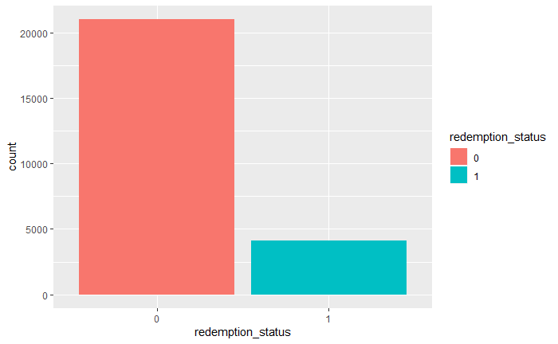

## Encode the categorical features of the data

```
   redemption_status campaign_duration X Y age_range marital_status rented family_size
1:                 0                47 1 0         2              1      0           0
2:                 0                48 1 0         3              0      0           1
3:                 0                40 1 0         2              0      0           4
4:                 0                48 1 0         3              0      0           1
5:                 0                47 1 0         3              0      0           1
6:                 0                47 1 0         0              0      0           1
   no_of_children income_bracket Established Local Bakery Dairy, Juices & Snacks
1:              3              1          43     0      0                      0
2:              3              4           0    31      0                      0
3:              2              7           2     0      0                      0
4:              3              4           5     0      0                      0
5:              3              9          11     0      0                      0
6:              3              3          83     0      0                      0
   Flowers & Plants Garden Grocery Meat Miscellaneous Natural Products Packaged Meat
```

[output cut: 20 more lines]

## Normalize the data

```
 redemption_status  campaign_duration       X                Y            age_range
 Min.   :0.000000   Min.   :0.0000    Min.   :0.0000   Min.   :0.0000   Min.   :0.0000
 1st Qu.:0.000000   1st Qu.:0.4516    1st Qu.:0.0000   1st Qu.:0.0000   1st Qu.:0.4000
 Median :0.000000   Median :0.4839    Median :1.0000   Median :0.0000   Median :0.6000
 Mean   :0.009252   Mean   :0.4098    Mean   :0.7297   Mean   :0.2703   Mean   :0.5371
 3rd Qu.:0.000000   3rd Qu.:0.5161    3rd Qu.:1.0000   3rd Qu.:1.0000   3rd Qu.:0.6000
 Max.   :1.000000   Max.   :1.0000    Max.   :1.0000   Max.   :1.0000   Max.   :1.0000
 marital_status       rented         family_size     no_of_children   income_bracket
 Min.   :0.0000   Min.   :0.00000   Min.   :0.0000   Min.   :0.0000   Min.   :0.0000
 1st Qu.:0.0000   1st Qu.:0.00000   1st Qu.:0.2500   1st Qu.:1.0000   1st Qu.:0.2727
 Median :0.0000   Median :0.00000   Median :0.2500   Median :1.0000   Median :0.3636
 Mean   :0.2078   Mean   :0.03248   Mean   :0.2813   Mean   :0.8704   Mean   :0.3534
 3rd Qu.:0.0000   3rd Qu.:0.00000   3rd Qu.:0.2500   3rd Qu.:1.0000   3rd Qu.:0.3636
 Max.   :1.0000   Max.   :1.00000   Max.   :1.0000   Max.   :1.0000   Max.   :1.0000
  Established            Local             Bakery         Dairy..Juices...Snacks
 Min.   :0.0000000   Min.   :0.00000   Min.   :0.000000   Min.   :0.000000
 1st Qu.:0.0001862   1st Qu.:0.00000   1st Qu.:0.000000   1st Qu.:0.000000
 Median :0.0008377   Median :0.00000   Median :0.000000   Median :0.000000
 Mean   :0.0067224   Mean   :0.01005   Mean   :0.005802   Mean   :0.006979
 3rd Qu.:0.0025130   3rd Qu.:0.00000   3rd Qu.:0.000000   3rd Qu.:0.000000
 Max.   :1.0000000   Max.   :1.00000   Max.   :1.000000   Max.   :1.000000
 Flowers...Plants       Garden            Grocery              Meat          Miscellaneous
 Min.   :0.000000   Min.   :0.000000   Min.   :0.000000   Min.   :0.000000   Min.   :0.000000
 1st Qu.:0.000000   1st Qu.:0.000000   1st Qu.:0.000000   1st Qu.:0.000000   1st Qu.:0.000000
 Median :0.000000   Median :0.000000   Median :0.001454   Median :0.000000   Median :0.000000
 Mean   :0.002545   Mean   :0.002539   Mean   :0.008113   Mean   :0.003477   Mean   :0.004565
 3rd Qu.:0.000000   3rd Qu.:0.000000   3rd Qu.:0.004361   3rd Qu.:0.000000   3rd Qu.:0.000000
 Max.   :1.000000   Max.   :1.000000   Max.   :1.000000   Max.   :1.000000   Max.   :1.000000
 Natural.Products   Packaged.Meat      Pharmaceutical     Prepared.Food          Salads
 Min.   :0.000000   Min.   :0.000000   Min.   :0.000000   Min.   :0.000000   Min.   :0.000000
 1st Qu.:0.000000   1st Qu.:0.000000   1st Qu.:0.000000   1st Qu.:0.000000   1st Qu.:0.000000
 Median :0.000000   Median :0.000000   Median :0.000000   Median :0.000000   Median :0.000000
 Mean   :0.002417   Mean   :0.004159   Mean   :0.002197   Mean   :0.003891   Mean   :0.001882
 3rd Qu.:0.000000   3rd Qu.:0.000000   3rd Qu.:0.000000   3rd Qu.:0.000000   3rd Qu.:0.000000
 Max.   :1.000000   Max.   :1.000000   Max.   :1.000000   Max.   :1.000000   Max.   :1.000000
    Seafood         Skin...Hair.Care      Travel         Vegetables..cut.     totquant
 Min.   :0.000000   Min.   :0.00000   Min.   :0.000000   Min.   :0.00000   Min.   :0.0000000
 1st Qu.:0.000000   1st Qu.:0.00000   1st Qu.:0.000000   1st Qu.:0.00000   1st Qu.:0.0005796
 Median :0.000000   Median :0.00000   Median :0.000000   Median :0.00000   Median :0.0120063
 Mean   :0.003009   Mean   :0.00167   Mean   :0.002027   Mean   :0.00237   Mean   :0.0525599
 3rd Qu.:0.000000   3rd Qu.:0.00000   3rd Qu.:0.000000   3rd Qu.:0.00000   3rd Qu.:0.0697727
 Max.   :1.000000   Max.   :1.00000   Max.   :1.000000   Max.   :1.00000   Max.   :1.0000000
  totmonetory         Freqcust         recency
 Min.   :0.00000   Min.   :0.0000   Min.   :0.000000
 1st Qu.:0.08457   1st Qu.:0.1463   1st Qu.:0.002331
 Median :0.14550   Median :0.2128   Median :0.006993
 Mean   :0.18181   Mean   :0.2536   Mean   :0.020249
 3rd Qu.:0.23594   3rd Qu.:0.3324   3rd Qu.:0.016317
 Max.   :1.00000   Max.   :1.0000   Max.   :1.000000
```

## Predictive Model and Evaluation

## Confusion Matrix

```
Confusion Matrix and Statistics

          Reference
Prediction     0     1
         0 15474    54
         1   104    41

               Accuracy : 0.9899
                 95% CI : (0.9882, 0.9914)
    No Information Rate : 0.9939
    P-Value [Acc > NIR] : 1

                  Kappa : 0.3368

 Mcnemar's Test P-Value : 9.69e-05

            Sensitivity : 0.431579
            Specificity : 0.993324
         Pos Pred Value : 0.282759
         Neg Pred Value : 0.996522
              Precision : 0.282759
                 Recall : 0.431579
                     F1 : 0.341667
             Prevalence : 0.006061
         Detection Rate : 0.002616
   Detection Prevalence : 0.009252
      Balanced Accuracy : 0.712451

       'Positive' Class : 1
```

## AUC

```
Area under the curve: 0.6396
```

## Plot ROC curve

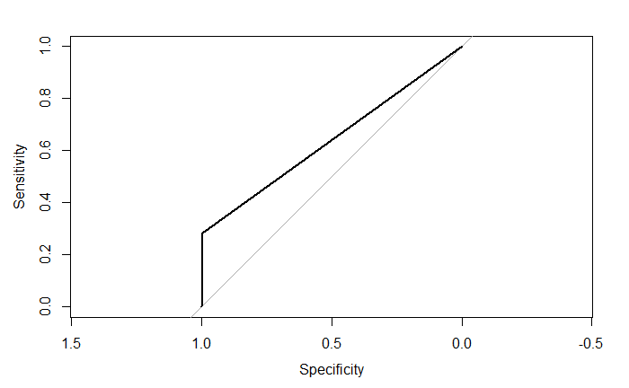

## AUC

```
Area under the curve: 0.5714
```

## Confusion Matrix

```
Confusion Matrix and Statistics

          Reference
Prediction     0     1
         0 15067   461
         1   120    25

               Accuracy : 0.9629
                 95% CI : (0.9599, 0.9658)
    No Information Rate : 0.969
    P-Value [Acc > NIR] : 1

                  Kappa : 0.0659

 Mcnemar's Test P-Value : <2e-16

            Sensitivity : 0.051440
            Specificity : 0.992099
         Pos Pred Value : 0.172414
         Neg Pred Value : 0.970312
              Precision : 0.172414
                 Recall : 0.051440
                     F1 : 0.079239
             Prevalence : 0.031009
         Detection Rate : 0.001595
   Detection Prevalence : 0.009252
      Balanced Accuracy : 0.521769

       'Positive' Class : 1
```

## ROC curve

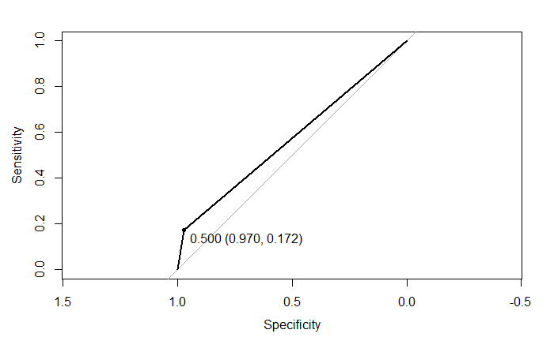

## AUC

```
Area under the curve: 0.9233
```

## Confusion Matrix

```
Confusion Matrix and Statistics

          Reference
Prediction     0     1
         0 15396   132
         1    21   124

               Accuracy : 0.9902
                 95% CI : (0.9886, 0.9917)
    No Information Rate : 0.9837
    P-Value [Acc > NIR] : 1.649e-12

                  Kappa : 0.6139

 Mcnemar's Test P-Value : < 2.2e-16

            Sensitivity : 0.484375
            Specificity : 0.998638
         Pos Pred Value : 0.855172
         Neg Pred Value : 0.991499
              Precision : 0.855172
                 Recall : 0.484375
                     F1 : 0.618454
             Prevalence : 0.016334
         Detection Rate : 0.007912
   Detection Prevalence : 0.009252
      Balanced Accuracy : 0.741506

       'Positive' Class : 1
```

## ROC curve

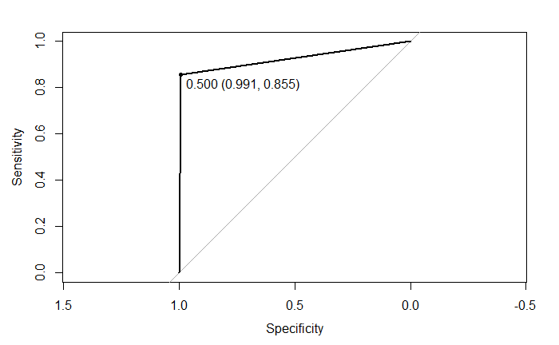

## XGBoost Model

Train the Model without normalization

## Confusion Matrix

```
Confusion Matrix and Statistics

          Reference
Prediction     0     1
         0 15462    66
         1   114    31

               Accuracy : 0.9885
                 95% CI : (0.9867, 0.9901)
    No Information Rate : 0.9938
    P-Value [Acc > NIR] : 1.0000000

                  Kappa : 0.2506

 Mcnemar's Test P-Value : 0.0004598

            Sensitivity : 0.319588
            Specificity : 0.992681
         Pos Pred Value : 0.213793
         Neg Pred Value : 0.995750
              Precision : 0.213793
                 Recall : 0.319588
                     F1 : 0.256198
             Prevalence : 0.006189
         Detection Rate : 0.001978
   Detection Prevalence : 0.009252
      Balanced Accuracy : 0.656134

       'Positive' Class : 1
```

## AUC

[output not shown]

## ROC curve

[figure not shown]